# GitHub Collaboration

Nathaniel Grimes

Renae Marshall

2022-10-13

## Introduction

Rent burden is a growing problem in the United States. However, the vast size and unique demographic composition of each state leads to variation in rent burdens. This analysis will visualize the difference in the different regions of the United States.

## Methods

Normally we would do a lot of fancy analysis like a multiple regression that could predict which factors lead to higher rent burden across states or regions. For simplicity we are only going to plot the differences at the region level. Then I challenge you to make your own graph with all the states rent burdens.

## Data

```r
#Load in base rent data
us_rent_df<-tidyr::us_rent_income

#get the regions and land area for each state
us_region<-state.region


# filter out non-states, then get the data into wider so we can calculate rent burden across the 3 regions
rent_summary<-us_rent_df %>%
  filter(!NAME %in%c("District of Columbia","Puerto Rico")) %>%
  pivot_wider(names_from = variable,values_from = c(estimate,moe)) %>%
  mutate(estimate_income=estimate_income/12) %>%  #Go from yearly to monthly
  mutate(burden_estimate=estimate_rent/estimate_income,burden_moe=moe_rent/moe_income) %>%
  mutate(region=as.character(us_region)) %>% #Add in the regions
  mutate(region=str_replace_all(region,"North Central","Midwest")) %>%  #It's the Midwest, not North Central I will throw hands on this
  group_by(region) %>%
  summarize(mean_burden=mean(burden_estimate),mean_moe=mean(burden_moe))
```

Normally we would do a lot of fancy analysis like a multiple regression that could predict which factors lead to higher rent burden across states or regions. For simplicity we are only going to plot the difference at the state and region level.

## Results

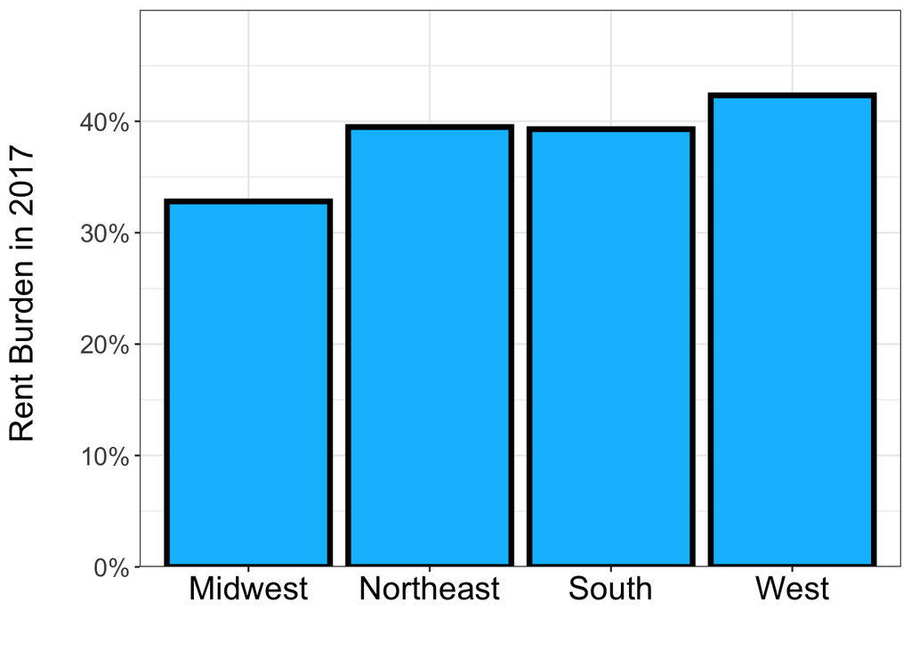

Figure 1. Rent burden as a percent of montly income across the four geographic regions of the US. Rent burdens are calculated by taking the median monthly rent and dividing by reported median motly income. Data taken from the 2017 American Community Survey

```r
region_bar<-ggplot(rent_summary,aes(x=region,y=mean_burden))+
  geom_col(fill="deepskyblue",color="black",size=1.5)+
  theme_bw()+
  labs(x="",y="Rent Burden in 2017 \n")+
  scale_y_continuous(labels=c("0%","10%","20%","30%","40%"),expand=c(0,0),limits=c(0,.5),breaks=seq(0,.4,by=.1))+
  theme(axis.text.y =  element_text(size=14))+
  theme(axis.text.x = element_text(size=18,color="black"))+
  theme(axis.title = element_text(size=18))

region_bar
```

```r
top5_state<-us_rent_df %>%
  filter(!NAME %in%c("District of Columbia","Puerto Rico")) %>%
  pivot_wider(names_from = variable,values_from = c(estimate,moe)) %>%
  mutate(estimate_income=estimate_income/12) %>%
  mutate(burden_estimate=estimate_rent/estimate_income,burden_moe=moe_rent/moe_income) %>%
  slice_max(order_by = burden_estimate,n=5) %>%
  mutate(pct=round(burden_estimate*100)) %>%
  select(NAME,pct)
```

```r
kable(top5_state,col.names = c("State","Rent Burden (%)"),format="html",caption = "Table 1.Top 5 States with the heaviest rent burdens in 2017") %>%
  kableExtra::kable_styling(font_size = 14)
```

Table 1.Top 5 States with the heaviest rent burdens in 2017

| State | Rent Burden (%) |
| --- | --- |
| Hawaii | 56 |
| California | 55 |
| Florida | 50 |
| New York | 46 |
| Alaska | 44 |

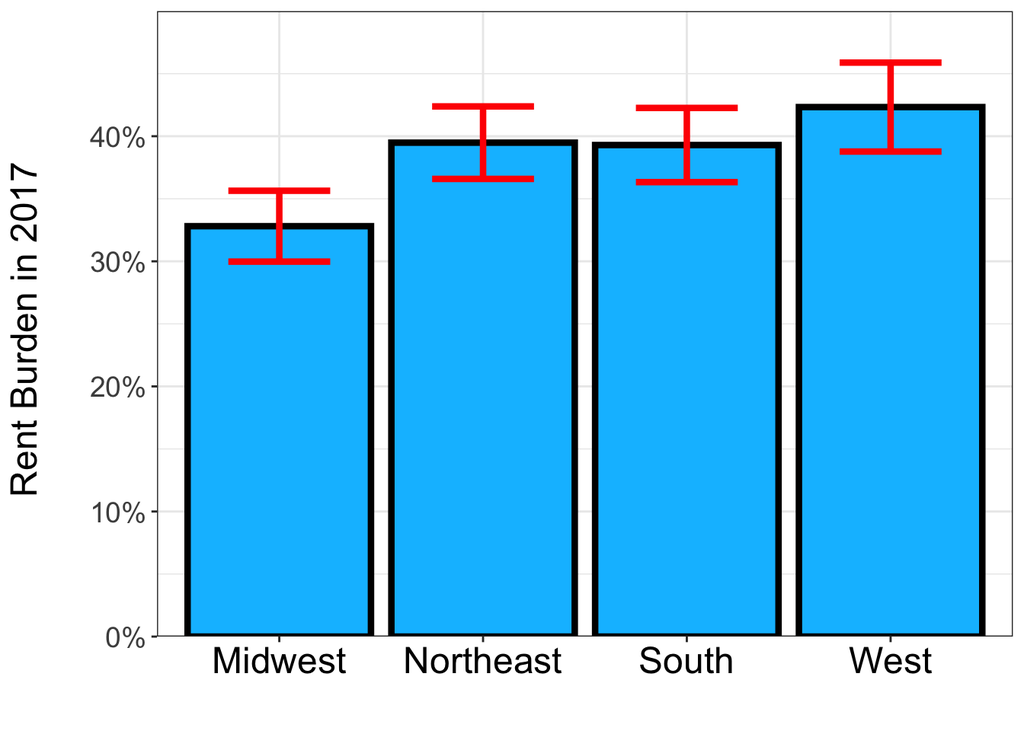

Figure 2. Look at those sexy 90% confidence intervals

```r
## Renae here's some quick code for you to adjust when we do the github in person demo Play around with the settings but I basically need you to add errorbars. You

region_bar+geom_errorbar(aes(ymin=mean_burden-mean_moe,ymax=mean_burden+mean_moe),width=0.5,size=1.5,color="red")
```

## Discussion

Yo this sucks and it’s only gotten worse. Strike for COLA!!